# Metagenome Analysis

Only ancestral, streptomycin and control treatments are included, unless otherwise stated.

Authors

Niina Smolander

Shane Hogle

# Libraries and functions

Prior to this analysis, the variants have been filtered using Mutect2’s FilterMutectCalls as well as separately for SNPs and INDELs using the following hard filtering factors: SOR, FS, MQ, MQRankSum, ReadPosRankSum, SNP/INDEL clustering (3/35) and SNP/INDEL proximity.

```r
library(tidyverse)
library(Polychrome)
library(withr)
library(fs)
library(compositions)
library(vegan)
library(qvalue)

source("data/input/utils_parallelism.R")
```

# Variants and annotations

```r
varfiles <- list.files(path = "data/input/tables_better_annotated/")

#
#
# x <- as.data.frame(varfiles) %>%
#   mutate(sample = str_split_i(varfiles, "-", 2)) %>%
#   mutate(sample = str_split_i(sample, "\\.", 1)) %>%
#   mutate(short = paste(str_split_i(sample, "_", 2),
#                        str_split_i(sample, "_", 3),
#                        sep = "_")) %>%
#   left_join(meta, by = join_by(short == Sample)) %>%
#   dplyr::select(sample, sample_short = short, home = Home, measure = Measure, timepoint = Timepoint, replicate = Replicate, home_env, measure_env, replicate_letter = replicate) %>%
#   distinct()
#
# write_tsv(x, "/Users/niinasmolander/Amanda_metagenomedata/samplecodes_info.tsv")
#
# x <- read_tsv("/Users/niinasmolander/Amanda_metagenomedata/samplecodes_info.tsv")

varfiles_snpeff <- varfiles[base::grep("snpeff", varfiles)]

variants <- list()
for(i in varfiles_snpeff){
  name <- str_remove(i, "_L003.VF.HF.snpeff.tsv")
  variants[[name]] <- read_tsv(paste0("data/input/tables_better_annotated/", i),
                               skip = 1,
                               col_names = c("CHROM",
                                             "POS",
                                             "REF",
                                             "ALT",
                                             "FILTER",
                                             "EFFECT",
                                             "IMPACT",
                                             "GENE",
                                             "BIOTYPE",
                                             "HGVS_C",
                                             "HGVS_P",
                                             "CDS_POS",
                                             "CDS_LEN",
                                             "AA_POS",
                                             "AA_LEN"),
                               col_types = c("cdcccccccccdddd"))
}


variants <- bind_rows(variants, .id = "Sample") %>%
  filter(FILTER == "PASS")

varfiles_variants <- varfiles[base::grep("variants", varfiles)]

variants2 <- list()
for(i in varfiles_variants){
  name <- str_remove(i, "_L003.VF.HF.variants.tsv")
  variants2[[name]] <- read_tsv(paste0("data/input/tables_better_annotated/", i),
                                skip = 1,
                                col_names = c("CHROM",
                                              "POS",
                                              "REF",
                                              "ALT",
                                              "FILTER",
                                              "TYPE",
                                              "AD",
                                              "AF",
                                              "DP",
                                              "FAD",
                                              "GQ",
                                              "VAF"),
                                col_types = c("cdcccccccccc"))
}


variants2 <- bind_rows(variants2, .id = "Sample") %>%
  filter(FILTER == "PASS")

# Combine and format rows with multiple ALTs

variants_all <- full_join(variants, variants2,
                          by = join_by(Sample, CHROM, POS, REF, ALT, FILTER)) %>%
  separate_wider_delim(cols = "Sample", delim = "-", names = c("HAMBI", "Sample"))


variants_all_tidy <- variants_all %>%
  separate_wider_delim(cols = "AD", delim = ",", names = c("REF_AD" ,"ALT1_AD", "ALT2_AD", "ALT3_AD", "ALT4_AD"), too_few = "align_start") %>%
  separate_wider_delim(cols = "FAD", delim = ",", names = c("REF_FAD" ,"ALT1_FAD", "ALT2_FAD", "ALT3_FAD", "ALT4_FAD"), too_few = "align_start") %>%
  mutate(ALT_AD = paste(ALT1_AD, ALT2_AD, ALT3_AD, ALT4_AD, sep = ","),
         ALT_FAD = paste(ALT1_FAD, ALT2_FAD, ALT3_FAD, ALT4_FAD, sep = ",")) %>%
  mutate(ALT_AD = str_remove_all(ALT_AD, ",NA"),
         ALT_FAD = str_remove_all(ALT_FAD, ",NA")) %>%
  select(-c("ALT1_AD", "ALT2_AD", "ALT3_AD", "ALT4_AD", "ALT1_FAD", "ALT2_FAD", "ALT3_FAD", "ALT4_FAD", "FILTER", "GQ")) %>%
  separate_longer_delim(cols = c("ALT", "AF", "VAF", "ALT_AD", "ALT_FAD"), delim = ",") %>%
  mutate(across(c("AF", "DP", "VAF", "REF_AD", "ALT_AD", "REF_FAD", "ALT_FAD"), as.numeric))
```

# Filtering

Keeping only the variants where allelic depth (AD) ≥ 5, coverage (DP) ≥ 5 and VAF ≥ 0.05. Also variants that are in mobile genetic elements are removed.

```r
# AD, DP and VAF
variants_all_tidy <- variants_all_tidy %>%
  filter(ALT_AD >= 5 & DP >= 5 & VAF >= 0.05)

# MGE
genomad <- read_tsv("data/input/MGE/genomad_HAMBI_combined.tsv",
                    skip = 1,
                    col_names = c("HAMBI",
                                  "CHROM",
                                  "Start",
                                  "End",
                                  "Name",
                                  "prediction_tool"),
                    col_types = c("ccddcc"))

mgefinder <- read_tsv("data/input/MGE/MGE_finder_HAMBI_combined.tsv",
                      skip = 1,
                      col_names = c("HAMBI",
                                    "Name",
                                    "CHROM",
                                    "Start",
                                    "End",
                                    "prediction_tool"),
                      col_types = c("cccddc"))


variants_all_tidy_mge <- variants_all_tidy %>%
  left_join(mgefinder, by = join_by(HAMBI, CHROM), relationship = "many-to-many") %>%
  filter(!(POS >= Start & POS <= End)) %>%
  dplyr::select(-Name, -Start, -End, -prediction_tool) %>%
  distinct() %>%
  left_join(genomad, by = join_by(HAMBI, CHROM), relationship = "many-to-many") %>%
  filter(!(POS >= Start & POS <= End)) %>%
  dplyr::select(-Name, -Start, -End, -prediction_tool) %>%
  distinct() %>%
  mutate(Sample = paste(str_split_i(Sample, "_", 2),
                        str_split_i(Sample, "_", 3),
                        sep = "_"))



##### change NAs to t0


# metadata
meta <- read_tsv("data/input/key.tsv") %>%
  dplyr::rename("Measure" = "Experiment",
                "Home" = "History")

variants_all_tidy_final <- left_join(variants_all_tidy_mge, meta,
                                     by = join_by(Sample))
# remove tetrahymena
variants_strep <- variants_all_tidy_final %>%
  filter(Measure != "Tetrahymena" & Measure != "Both") %>%
  filter(Home != "Tetrahymena" & Home != "Both")

variants_non_syn <- variants_strep %>%
  filter(EFFECT != "synonymous_variant")

variants_all_filt <- variants_strep %>%
  # exclude intragenic, intergenic, and synonymous mutations. Also exclude
  # fusion functions because these are weird and also rare. Excluding the
  # modifier category also ensures that we filter out any tRNAs with mutations
  filter(!str_detect(EFFECT, "intergenic|intragenic|synonymous|fusion")) %>%
  filter(!str_detect(IMPACT, "MODIFIER"))



#write_rds(variants_strep, "data/input/variants_strep.rds")
```

# 1) Types of mutations by HAMBI and sample type

```r
mutation_counts <- variants_strep %>%
  select(HAMBI, measure_env, home_env, Timepoint, EFFECT) %>%
  group_by(HAMBI, measure_env, home_env, Timepoint, EFFECT) %>%
  summarise(n = n()) %>% ungroup()
```

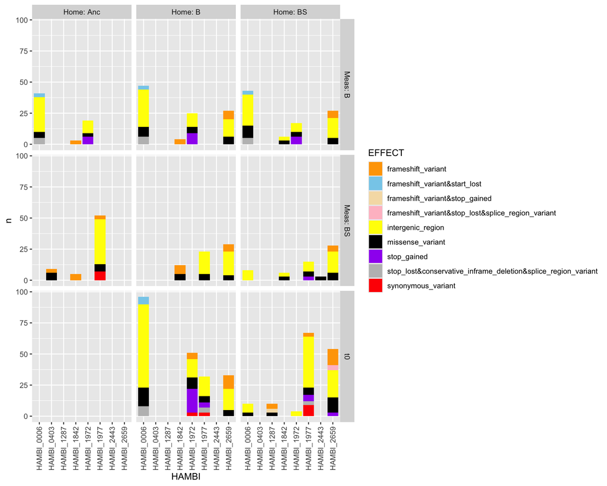

```r
mutation_counts %>% filter(n > 2) %>%
  ggplot(aes(x = HAMBI, y = n, fill = EFFECT)) +
  geom_bar(stat = "identity") +
  facet_grid(measure_env ~ home_env) +
  scale_fill_manual(values = c("orange",
                               "skyblue",
                               "wheat",
                               "pink",
                               "yellow",
                               "black",
                               "purple",
                               "gray",
                               "red"))+
  theme(axis.text.x = element_text(angle = 90, vjust = 0.5, hjust=1))
```

```r
                               # "purple",
                               # "gold",
                               # "darkgreen"
```

## 1.2) No intergenic mutations

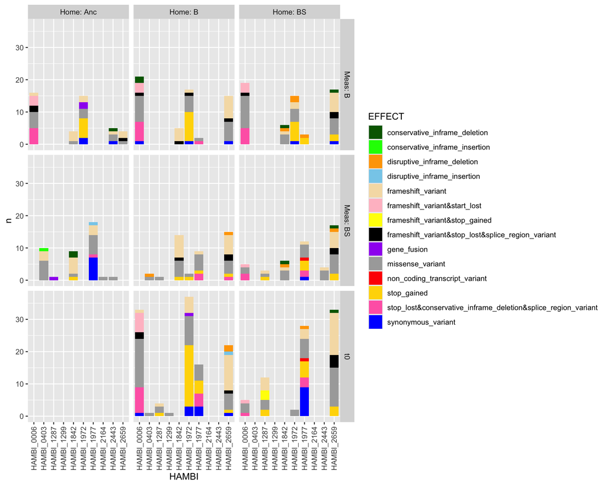

```r
mutation_counts %>% filter(EFFECT != "intergenic_region") %>%
  ggplot(aes(x = HAMBI, y = n, fill = EFFECT)) +
  geom_bar(stat = "identity") +
  facet_grid(measure_env ~ home_env) +
  scale_fill_manual(values = c("darkgreen",
                               "green",
                               "orange",
                               "skyblue",
                               "wheat",
                               "pink",
                               "yellow",
                               "black",
                               "purple",
                               "darkgray",
                               "red",
                               "gold",
                               "hotpink",
                               "blue"))+
  theme(axis.text.x = element_text(angle = 90, vjust = 0.5, hjust=1))
```

```r
                               # "purple",
                               # "gold",
                               # "darkgreen"
```

# 2) Constrained Analysis of Principal Coordinates

Using Bray-Curtis dissimilarity.

```r
# prep data
var_matrix_all <- variants_all_tidy_final %>%
  mutate(var_id = paste(CHROM, POS, ALT, sep = "_")) %>%
  select(var_id, Measure, Home, Timepoint, Replicate, Sample, VAF) %>%
  pivot_wider(names_from = var_id, values_from = VAF, values_fill = 0) %>%
  as.data.frame(.)

rownames(var_matrix_all) <- var_matrix_all$Sample

var_matrix <- variants_strep %>%
  mutate(var_id = paste(CHROM, POS, ALT, sep = "_")) %>%
  select(var_id, Measure, Home, Timepoint, Replicate, Sample, VAF) %>%
  pivot_wider(names_from = var_id, values_from = VAF, values_fill = 0) %>%
  as.data.frame(.)

rownames(var_matrix) <- var_matrix$Sample

var_matrix_nonsyn <- variants_non_syn %>%
  mutate(var_id = paste(CHROM, POS, ALT, sep = "_")) %>%
  select(var_id, Measure, Home, Timepoint, Replicate, Sample, VAF) %>%
  pivot_wider(names_from = var_id, values_from = VAF, values_fill = 0) %>%
  as.data.frame(.)

rownames(var_matrix_nonsyn) <- var_matrix_nonsyn$Sample


var_matrix_all_filt <- variants_all_filt %>%
  mutate(var_id = paste(CHROM, POS, ALT, sep = "_")) %>%
  select(var_id, Measure, Home, Timepoint, Replicate, Sample, VAF) %>%
  pivot_wider(names_from = var_id, values_from = VAF, values_fill = 0) %>%
  as.data.frame(.)

rownames(var_matrix_all_filt) <- var_matrix_all_filt$Sample


# capscale
cap_results_all <- vegan::capscale(var_matrix_all[-(1:5)] ~ Home*Measure,
                               data = var_matrix_all,
                               dist = "bray")


cap_results <- vegan::capscale(var_matrix[-(1:5)] ~ Home*Measure,
                               data = var_matrix,
                               dist = "bray")

cap_results_nonsyn <- vegan::capscale(var_matrix_nonsyn[-(1:5)] ~ Home*Measure,
                               data = var_matrix_nonsyn,
                               dist = "bray")

cap_results_all_filt <- vegan::capscale(var_matrix_all_filt[-(1:5)] ~ Home*Measure,
                               data = var_matrix_all_filt,
                               dist = "bray")


# plot prep all
baseplot_all <- plot(cap_results_all)
```

```r
sites_all <- data.frame(baseplot_all$sites)
sites_all$Sample <- rownames(sites_all)
sites_all <- dplyr::left_join(sites_all, select(var_matrix_all, Home, Measure, Timepoint, Replicate, Sample), by = join_by(Sample)) %>%
  left_join(meta, by = join_by(Home, Measure, Timepoint, Replicate, Sample))

# plot prep strep
baseplot <- plot(cap_results)
```

```r
sites <- data.frame(baseplot$sites)
sites$Sample <- rownames(sites)
sites <- dplyr::left_join(sites, select(var_matrix, Home, Measure, Timepoint, Replicate, Sample), by = join_by(Sample)) %>%
  left_join(meta, by = join_by(Home, Measure, Timepoint, Replicate, Sample))


# plot prep non synonymous
baseplot_nonsyn <- plot(cap_results_nonsyn)
```

```r
sites_nonsyn <- data.frame(baseplot_nonsyn$sites)
sites_nonsyn$Sample <- rownames(sites_nonsyn)
sites_nonsyn <- dplyr::left_join(sites_nonsyn, select(var_matrix_nonsyn, Home, Measure, Timepoint, Replicate, Sample), by = join_by(Sample)) %>%
  left_join(meta, by = join_by(Home, Measure, Timepoint, Replicate, Sample))


# plot prep all filt
baseplot_all_filt <- plot(cap_results_all_filt)
```

```r
sites_all_filt <- data.frame(baseplot_all_filt$sites)
sites_all_filt$Sample <- rownames(sites_all_filt)
sites_all_filt <- dplyr::left_join(sites_all_filt, select(var_matrix_nonsyn, Home, Measure, Timepoint, Replicate, Sample), by = join_by(Sample)) %>%
  left_join(meta, by = join_by(Home, Measure, Timepoint, Replicate, Sample))
```

## 2.1) CAP plot for the whole data (incl. tetrahymena samples)

First plot split by Home, the second one split by Measure. t0 refers to the timepoint 0 (start of the experiment). Letters in the dots indicate the replicate.

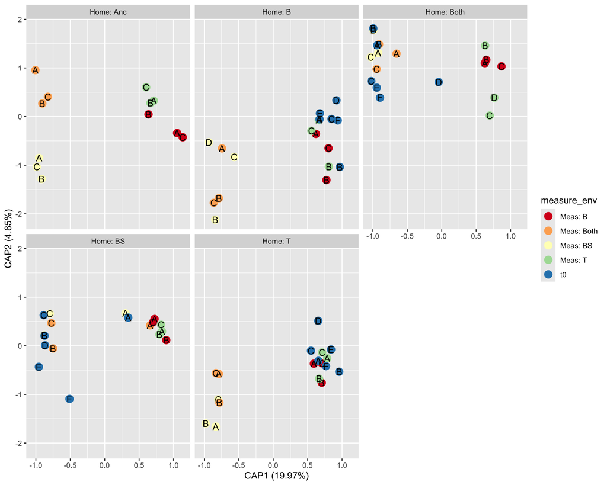

```r
ggplot() +
  geom_point(data=sites_all, aes(x=CAP1, y=CAP2, color=measure_env), alpha = 1.5, size = 4) +
  labs(x = paste0("CAP1 (", round(summary(vegan::eigenvals(cap_results_all))[2,1] *100, 2)
, "%)"),
       y = paste0("CAP2 (", round(summary(vegan::eigenvals(cap_results_all))[2,2] *100, 2)
, "%)")) +
  geom_text(data = sites_all, aes(x = CAP1, y = CAP2, label = replicate)) +
  facet_wrap(home_env ~ .) +
  scale_color_brewer(palette = "Spectral")
```

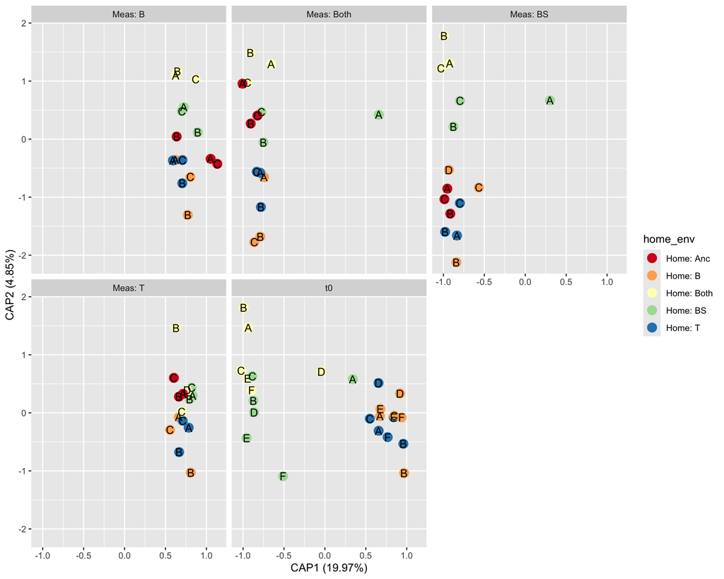

```r
ggplot() +
  geom_point(data=sites_all, aes(x=CAP1, y=CAP2, color=home_env), alpha = 1.5, size = 4) +
  labs(x = paste0("CAP1 (", round(summary(vegan::eigenvals(cap_results_all))[2,1] *100, 2)
, "%)"),
       y = paste0("CAP2 (", round(summary(vegan::eigenvals(cap_results_all))[2,2] *100, 2)
, "%)")) +
  geom_text(data = sites_all, aes(x = CAP1, y = CAP2, label = replicate)) +
  facet_wrap(measure_env ~ .) +
  scale_color_brewer(palette = "Spectral")
```

```r
anova.cca(cap_results_all, by = "terms")
```

|  | Df | SumOfSqs | F | Pr(>F) |
| --- | --- | --- | --- | --- |
| Home | 4 | 3.593545 | 3.218538 | 0.001 |
| Measure | 4 | 5.174203 | 4.634245 | 0.001 |
| Home:Measure | 15 | 4.687746 | 1.119614 | 0.133 |
| Residual | 60 | 16.747720 | NA | NA |

## 2.2) CAP plots for the no-tetrahymena data

First plot split by Home, second one split by Measure. t0 refers to the timepoint 0 (start of the experiment). Letters in the dots indicate the replicate.

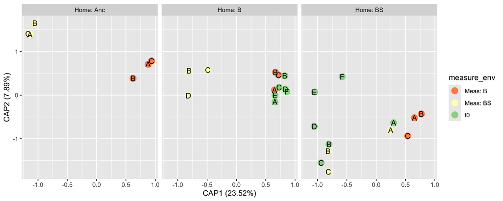

```r
ggplot() +
  geom_point(data=sites, aes(x=CAP1, y=CAP2, color=measure_env), alpha = 1.5, size = 4) +
  labs(x = paste0("CAP1 (", round(summary(vegan::eigenvals(cap_results))[2,1] *100, 2)
, "%)"),
       y = paste0("CAP2 (", round(summary(vegan::eigenvals(cap_results))[2,2] *100, 2)
, "%)")) +
  geom_text(data = sites, aes(x = CAP1, y = CAP2, label = replicate)) +
  facet_wrap(home_env ~ .) +
  scale_color_brewer(palette = "Spectral")
```

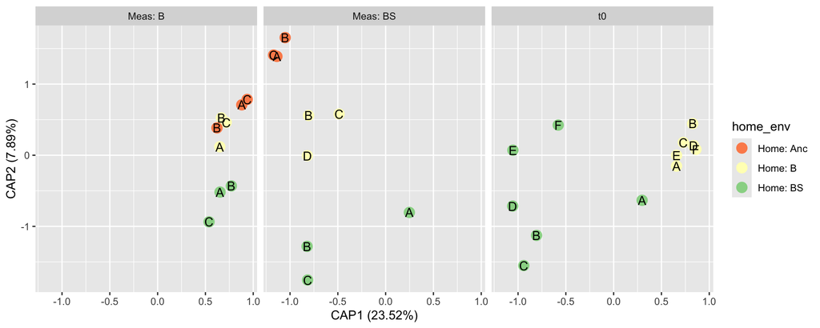

```r
ggplot() +
  geom_point(data=sites, aes(x=CAP1, y=CAP2, color=home_env), alpha = 1.5, size = 4) +
  labs(x = paste0("CAP1 (", round(summary(vegan::eigenvals(cap_results))[2,1] *100, 2)
, "%)"),
       y = paste0("CAP2 (", round(summary(vegan::eigenvals(cap_results))[2,2] *100, 2)
, "%)")) +
  geom_text(data = sites, aes(x = CAP1, y = CAP2, label = replicate)) +
  facet_wrap(measure_env ~ .) +
  scale_color_brewer(palette = "Spectral")
```

```r
anova.cca(cap_results, by = "terms")
```

|  | Df | SumOfSqs | F | Pr(>F) |
| --- | --- | --- | --- | --- |
| Home | 2 | 1.423304 | 2.700730 | 0.002 |
| Measure | 2 | 1.648204 | 3.127478 | 0.001 |
| Home:Measure | 3 | 1.121291 | 1.418438 | 0.067 |
| Residual | 22 | 5.797080 | NA | NA |

## 2.3) CAP plots for the non-synonymous variants

First plot split by Home, second one split by Measure. t0 refers to the timepoint 0 (start of the experiment). Letters in the dots indicate the replicate.

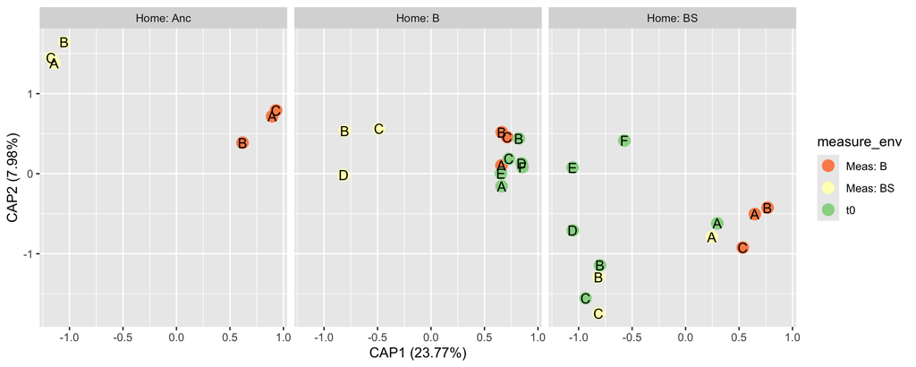

```r
ggplot() +
  geom_point(data=sites_nonsyn, aes(x=CAP1, y=CAP2, color=measure_env), alpha = 1.5, size = 4) +
  labs(x = paste0("CAP1 (", round(summary(vegan::eigenvals(cap_results_nonsyn))[2,1] *100, 2)
, "%)"),
       y = paste0("CAP2 (", round(summary(vegan::eigenvals(cap_results_nonsyn))[2,2] *100, 2)
, "%)")) +
  geom_text(data = sites_nonsyn, aes(x = CAP1, y = CAP2, label = replicate)) +
  facet_wrap(home_env ~ .) +
  scale_color_brewer(palette = "Spectral")
```

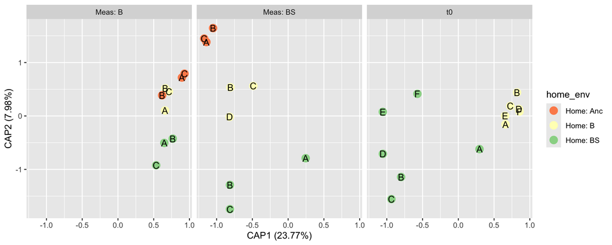

```r
ggplot() +
  geom_point(data=sites_nonsyn, aes(x=CAP1, y=CAP2, color=home_env), alpha = 1.5, size = 4) +
  labs(x = paste0("CAP1 (", round(summary(vegan::eigenvals(cap_results_nonsyn))[2,1] *100, 2)
, "%)"),
       y = paste0("CAP2 (", round(summary(vegan::eigenvals(cap_results_nonsyn))[2,2] *100, 2)
, "%)")) +
  geom_text(data = sites_nonsyn, aes(x = CAP1, y = CAP2, label = replicate)) +
  facet_wrap(measure_env ~ .) +
  scale_color_brewer(palette = "Spectral")
```

```r
anova.cca(cap_results_nonsyn, by = "terms")
```

|  | Df | SumOfSqs | F | Pr(>F) |
| --- | --- | --- | --- | --- |
| Home | 2 | 1.429235 | 2.733488 | 0.001 |
| Measure | 2 | 1.654962 | 3.165203 | 0.001 |
| Home:Measure | 3 | 1.123833 | 1.432927 | 0.070 |
| Residual | 22 | 5.751473 | NA | NA |

## 2.4) CAP plots for heavily filtered variants

Intragenic, intergenic, synonymous, fusion and modifier mutations filtered out. First plot split by Home, second one split by Measure. t0 refers to the timepoint 0 (start of the experiment). Letters in the dots indicate the replicate.

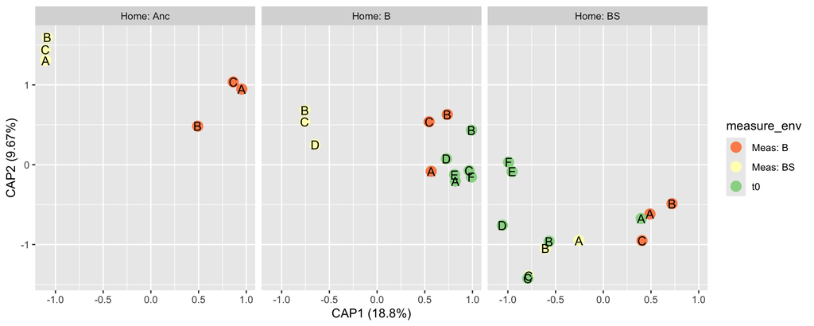

```r
ggplot() +
  geom_point(data=sites_all_filt, aes(x=CAP1, y=CAP2, color=measure_env), alpha = 1.5, size = 4) +
  labs(x = paste0("CAP1 (", round(summary(vegan::eigenvals(cap_results_all_filt))[2,1] *100, 2)
, "%)"),
       y = paste0("CAP2 (", round(summary(vegan::eigenvals(cap_results_all_filt))[2,2] *100, 2)
, "%)")) +
  geom_text(data = sites_all_filt, aes(x = CAP1, y = CAP2, label = replicate)) +
  facet_wrap(home_env ~ .) +
  scale_color_brewer(palette = "Spectral")
```

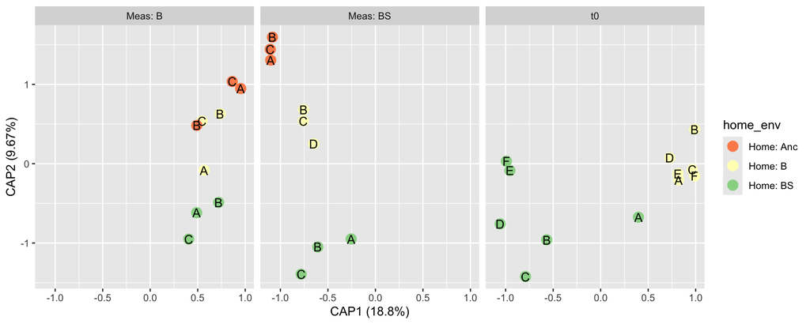

```r
ggplot() +
  geom_point(data=sites_all_filt, aes(x=CAP1, y=CAP2, color=home_env), alpha = 1.5, size = 4) +
  labs(x = paste0("CAP1 (", round(summary(vegan::eigenvals(cap_results_all_filt))[2,1] *100, 2)
, "%)"),
       y = paste0("CAP2 (", round(summary(vegan::eigenvals(cap_results_all_filt))[2,2] *100, 2)
, "%)")) +
  geom_text(data = sites_all_filt, aes(x = CAP1, y = CAP2, label = replicate)) +
  facet_wrap(measure_env ~ .) +
  scale_color_brewer(palette = "Spectral")
```

```r
anova.cca(cap_results_all_filt, by = "terms")
```

|  | Df | SumOfSqs | F | Pr(>F) |
| --- | --- | --- | --- | --- |
| Home | 2 | 1.636800 | 2.848565 | 0.001 |
| Measure | 2 | 1.379252 | 2.400349 | 0.002 |
| Home:Measure | 3 | 1.030711 | 1.195848 | 0.183 |
| Residual | 22 | 6.320656 | NA | NA |

## 2.5) Distances between the timepoints t3 and t0

Distance between the t3 and t0 points in the CAP plot for each Home-Measure combination where two timepoints existed.

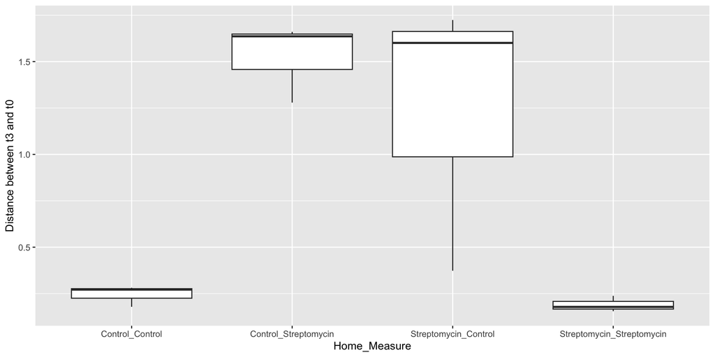

```r
test_t0 <- sites %>% select(-Sample) %>%
  filter(Timepoint == "t0")

test_t3 <- sites %>% select(-Sample) %>%
  filter(Timepoint == "t3" & Home != "Ancestor")

test <- right_join(test_t0, test_t3,
          by = join_by(Home, Replicate),
          suffix = c("_t0", "_t3")) %>%
  select(-c("Measure_t0", "Timepoint_t0", "Timepoint_t3")) %>%
  rename("Measure" = "Measure_t3") %>%
  mutate(CAP1_dist = (CAP1_t0 - CAP1_t3)^2,
         CAP2_dist = (CAP2_t0 - CAP2_t3)^2) %>%
  mutate(dist = sqrt(CAP1_dist + CAP2_dist)) %>%
  mutate(Home_Measure = paste(Home, Measure, sep = "_"))

test %>%
  ggplot(aes(x = Home_Measure, y = dist)) +
  geom_boxplot() +
  labs(y = "Distance between t3 and t0")
```

# 3) t-distributed Stochastic Neighbor Embedding (tSNE)

```r
balclr <- compositions::clr(var_matrix_nonsyn[-(1:5)])

balclr2 <- compositions::clr(var_matrix[-(1:5)])

var_matrix_tsne <- Rtsne::Rtsne(as.matrix(balclr), perplexity = 5, dims = 2, max_iter = 100000)
var_matrix_tsne2 <- Rtsne::Rtsne(as.matrix(balclr2), perplexity = 5, dims = 2, max_iter = 100000)


tSNE_for_plot <- var_matrix_tsne$Y %>%
  cbind(dplyr::distinct(dplyr::select(var_matrix_nonsyn, Sample, Replicate, Home, Measure, Timepoint))) %>%
  rename("tSNE1" = "1",
         "tSNE2" = "2") %>%
  left_join(meta, by = join_by(Home, Measure, Timepoint, Replicate, Sample))

tSNE_for_plot2 <- var_matrix_tsne2$Y %>%
  cbind(dplyr::distinct(dplyr::select(var_matrix, Sample, Replicate, Home, Measure, Timepoint))) %>%
  rename("tSNE1" = "1",
         "tSNE2" = "2") %>%
  left_join(meta, by = join_by(Home, Measure, Timepoint, Replicate, Sample))
```

## 3.1) tSNE plot with non-synonymous variants data

First plot split by Home, second one split by Measure. t0 refers to the timepoint 0 (start of the experiment). Letters in the dots indicate the replicate.

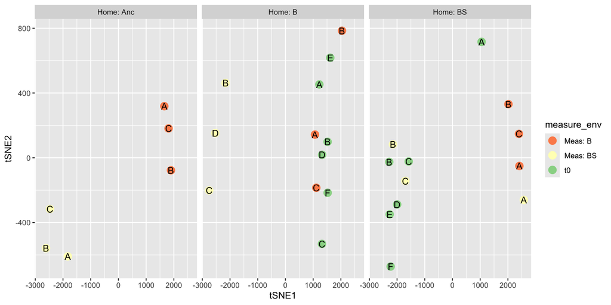

```r
ggplot() +
  geom_point(data=tSNE_for_plot, aes(x=tSNE1, y=tSNE2, color=measure_env), alpha = 1.5, size = 4) +
  geom_text(data = tSNE_for_plot, aes(x=tSNE1, y=tSNE2, label = replicate)) +
  facet_wrap(home_env ~ .) +
  scale_color_brewer(palette = "Spectral")
```

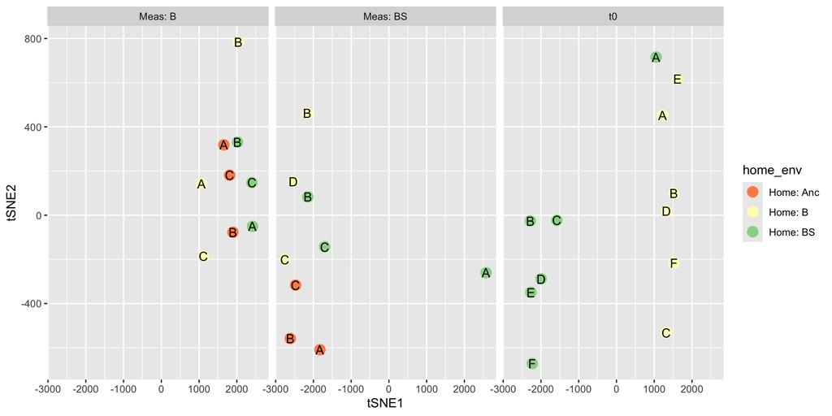

```r
ggplot() +
  geom_point(data=tSNE_for_plot, aes(x=tSNE1, y=tSNE2, color=home_env), alpha = 1.5, size = 4) +
  geom_text(data = tSNE_for_plot, aes(x=tSNE1, y=tSNE2, label = replicate)) +
  facet_wrap(measure_env ~ .) +
  scale_color_brewer(palette = "Spectral")
```

## 3.2) tSNE plot with all variants data

First plot split by Home, second one split by Measure. t0 refers to the timepoint 0 (start of the experiment). Letters in the dots indicate the replicate.

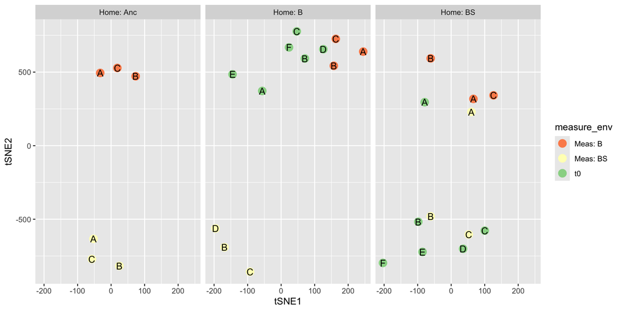

```r
ggplot() +
  geom_point(data=tSNE_for_plot2, aes(x=tSNE1, y=tSNE2, color=measure_env), alpha = 1.5, size = 4) +
  geom_text(data = tSNE_for_plot2, aes(x=tSNE1, y=tSNE2, label = replicate)) +
  facet_wrap(home_env ~ .) +
  scale_color_brewer(palette = "Spectral")
```

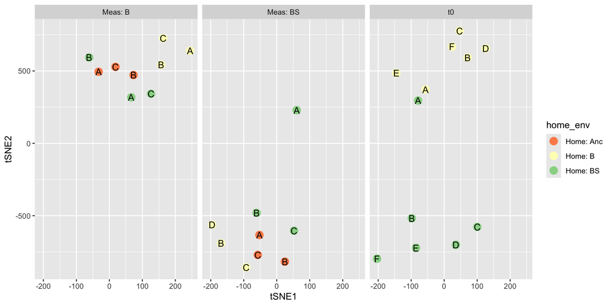

```r
ggplot() +
  geom_point(data=tSNE_for_plot2, aes(x=tSNE1, y=tSNE2, color=home_env), alpha = 1.5, size = 4) +
  geom_text(data = tSNE_for_plot2, aes(x=tSNE1, y=tSNE2, label = replicate)) +
  facet_wrap(measure_env ~ .) +
  scale_color_brewer(palette = "Spectral")
```